# Simulation of ChIP-seq data

Maurits Evers

17 February 2017

# 1 Introduction

[`ChIPsim`](https://www.bioconductor.org/packages/release/bioc/html/ChIPsim.html) provides a framework for the simulation of ChIP-seq data. This is worked-through example of how to use `ChIPsim` for the simulation of data from a transcription factor binding ChIP-seq experiment, and is based on the “Advanced model” from the [`ChIPsim` vignette](https://www.bioconductor.org/packages/devel/bioc/vignettes/ChIPsim/inst/doc/ChIPsimIntro.pdf). Briefly, the simulation process involves the following steps:

1. Definition of a Markov chain model that describes transitions between background and binding regions.
2. Generation of background and binding regions.
3. Conversion of background and binding regions to reference-wide binding site densities.
4. Generation of read densities from binding site densities.
5. Output of background and binding region-associated reads.

# 2 Prerequisities

We start by loading necessary R packages and set a fixed seed (for ensuring results reproducibility).

```r
suppressMessages(library(Biostrings));  # For DNAStringSet
suppressMessages(library(ChIPsim));     # Main package for ChIP-seq data simulation
suppressMessages(library(ggplot2));     # For plotting
suppressMessages(library(actuar));      # For pareto distribution
suppressMessages(library(reshape2));    # For melt (convert wide df to long df)
set.seed(1234);
```

We simulate transcription factor ChIP-seq reads from the human GRCh38 mitochondrial DNA sequence. We need to read in the reference sequence in order to estimate the size of the reference.

```r
genome <- readDNAStringSet("GRCh38_MT.fa.gz");
refLength <- width(genome);
print(refLength);
```

```
## [1] 16569
```

# 3 Markov chain parameters

We define a transition matrix $P$ that describes the transition probabilities of the model’s Markov chain. Here we require that a binding region is followed by a background region, and that multiple background regions are allowed to follow each other.

$$P = \left(\begin{array}{c|cc} & P_\text{Binding} & P_\text{Background} \\\hline P_\text{Binding} & 0.00 & 1.00 \\ P_\text{Background} & 0.05 & 0.95 \end{array}\right)$$

```r
# Transition probabilities
# Note that a binding region has to be followed by a background region,
# while background regions are allowed to follow each other.
#       Bind  Back
#       ----------
# P =   0.00  1.00  | Bind
#       0.05  0.95  | Back
transition <- list(
    Binding = c(Background = 1),
    Background = c(Binding = 0.05, Background = 0.95)
);
transition <- lapply(transition, "class<-", "StateDistribution");
```

Next we define the initial state of the Markov chain
$$x^{(0)} = \left(\begin{array}{c}0 \\ 1\end{array}\right)\,.$$

```r
# Start Markov chain with background
init <- c(Binding = 0, Background = 1);
class(init) <- "StateDistribution";
```

# 4 Background and binding region characterisation

## 4.1 Sampling weight distributions

We now define two functions that characterise the background and binding regions.

**Comment:** Two critical parameters here are the length of a background and binding region. See my comment in section 4.2 about the possible error in `ChIPsim::placeFeatures`.

### 4.1.1 Background regions

We use a gamma distribution to model the background sampling weight for each background region

$$\begin{align}
w_\text{Background} &\sim \text{Gamma}(k, \theta) \\
f_X^\text{Gamma}(x) &= \frac{1}{\Gamma(k)\theta^k}x^{k-1}e^{-\frac{x}{\theta}}\,,
\end{align}$$

```r
# Define background region length
#backgroundLength <- 1000;
backgroundLength <- 500;
# Define function to generate the parameters for background regions.
# Here we use a gamma distribution to model the background sampling weight
# for each region.
backgroundFeature <- function(
    start,
    length = backgroundLength,
    shape = 1,
    scale = 20) {
    weight <- rgamma(1, shape = 1, scale = 20);
    params <- list(start = start, length = length, weight = weight);
    class(params) <- c("Background", "SimulatedFeature");
    return(params);
}
```

### 4.1.2 Binding regions

For the binding regions, we use a Pareto distribution to model the binding region sampling weights
$$\begin{align}
w_\text{Binding} &\sim \text{ParetoI}(r, x_m) \\
f_X^\text{ParetoI}(x) &= \begin{cases} \dfrac{r x_m^r}{x^{r+1}} & x \geq x_m\,, \\[2ex] 0 & x < x_m\,.\end{cases}
\end{align}$$
We use $r = 1.5$ and choose $x_m$ such that the mean of the distribution is equal to the mean of the background sampling weight distribution times an enrichment factor $t$
$$\begin{equation}
\label{eq:matchingCondition}
\text{mean}(f_X^\text{Pareto}(x)) = \text{mean}(f_X^\text{Gamma}) \times t = k \times \theta \times t\,.
\end{equation}$$

Binding regions are set to span a width of 50 bp.

```r
# Define binding region length
bindingLength = 50;
# Define function to generate the parameters for binding regions.
# Here we set the sampling weight for binding sites to be the average
# weight of background regions multiplied by and enrichment coefficient.
# w_binding' = t x mean(w_background). We use a Pareto distribution
# with parameter r to determine w_binding for each binding site. The
# minimum of the distribution is chosen such that its mean is w_binding'.
bindingFeature <- function(
    start,
    length = bindingLength,
    shape = 1,
    scale = 20,
    enrichment = 5,
    r = 1.5) {
    stopifnot(r > 1);
    avgWeight <- shape * scale * enrichment;
    lowerBound <- (r - 1) * avgWeight;
    weight <- actuar::rpareto1(1, r, lowerBound);
    params <- list(start = start, length = length, weight = weight);
    class(params) <- c("Binding", "SimulatedFeature");
    return(params);
}
```

**Comment:** I am not entirely clear on the parametrisation of the `actuar::rpareto1` Pareto function’s lower bound $x_m$ used here. Following the standard parametrisation of the Pareto Type I distribution, I would have expected `lowerBound <- (r - 1) * avgWeight / r`, since $\text{mean}(f_X^\text{Pareto}) = (r x_m) / (r-1)$.

## 4.2 Markov chain-modelling of binding and background regions

We are now ready to generate background and binding site loci.

```r
# Generate feature sequences
# Note that this generates a list of background and binding sites, based
# on the transition probabilities of the Markov chain model, and on the
# sampling weights for background and binding sites defined by the two
# functions backgroundFeature() and bindingFeatures().
generator <- list(
    Binding = bindingFeature,
    Background = backgroundFeature);
features <- ChIPsim::placeFeatures(
    generator,
    transition,
    init,
    start = 0,
    length = refLength,
    globals = list(shape = 1, scale = 20),
    experimentType = "TFExperiment",
    lastFeat = c(Binding = FALSE, Background = TRUE));
```

**Comment:** The function `ChIPsim::placeFeatures` throws an error if I have `backgroundLength = 1000` and `length = refLength = width(genome)` (or explicitly `length = 16569`): `Error in sample.int(length(x), size, replace, prob): invalid first argument`. I am not entirely clear on why this happens. A `traceback()` shows that the error originates from the line `sample(names(transition[[class(init)[1]]]), 1, prob = transition[[class(init)[1]]])` within the `makeFeatures` function. The error disappears if we *increase* `refLength`, or *decrease* `lengthBackground`. Therefore I have the suspicion that the error appears if the Markov model yields no binding sites; in the case here where `backgroundLength = 500` and `refLength = width(genome)` we end up with only one single binding site, but no error. If we want to generalise this to arbitrarily large/small reference sequences we probably need to have implement a check before running `ChIPsim::placeFeatures`. One possibility would be to re-run the Markov model with different seeds until we have *at least* one binding site.

Here we make the following assumptions:

1. We model background and binding regions in the spatial interval [0, 16569] bp.
2. We ensure that shape and scale parameters are consistent across the background and binding region sampling weight distributions. with matching conditions as defined in Eq. $\eqref{eq:matchingCondition}$.
3. We also require that the last feature is a background region.

The resulting object `features` contains a list of binding and background regions

```r
table(sapply(features, class));
```

```
##
##        Background           Binding ReconciledFeature  SimulatedFeature
##                33                 1                34                34
```

Every region is characterised by a start position, a length, and a sampling weight, e.g.

```r
features[[1]];
```

```
## Object of class Background (reconciled)
## start: 1
## length: 500
## weight: 14.89088
## overlap: 0
```

We plot the distribution of sampling weights for the modelled background and binding regions.

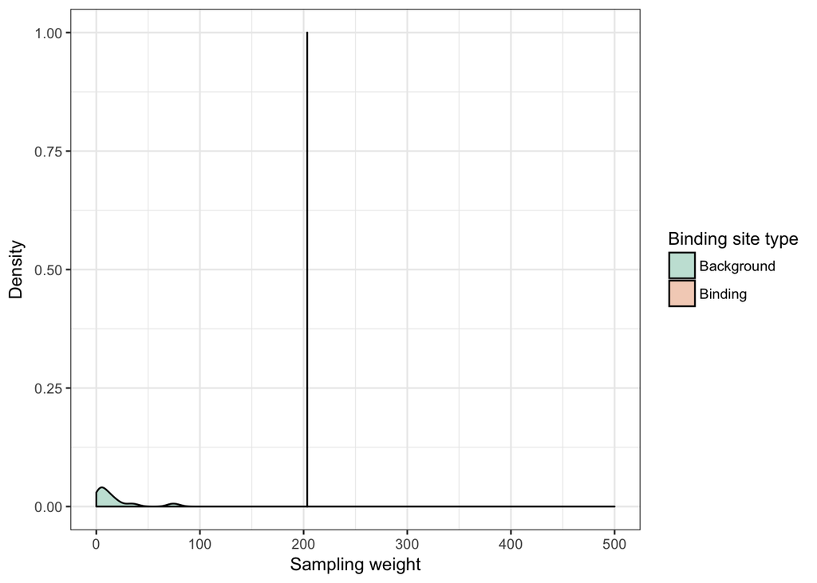

```r
# We plot the distribution of sampling weights for the derived background
# and binding sites.
df <- cbind.data.frame(
    weight = sapply(features, "[[", "weight"),
    type = sapply(features, function(x) class(x)[1]));
gg <- ggplot(subset(df, weight <= 500), aes(weight, fill = type));
gg <- gg + geom_density(alpha = 0.3);
gg <- gg + theme_bw();
gg <- gg + scale_fill_brewer(palette = "Dark2");
gg <- gg + xlim(0, 500);
gg <- gg + labs(
    x = "Sampling weight",
    y = "Density",
    fill = "Binding site type");
gg;
```

Note: The `ChIPsim` vignette states that in this case we can also use `ChIPsim::makeFeatures` instead of `ChIPsim::placeFeatures` to generate features. Generally, there seems to be a lack of consistency betwen the return objects of `ChIPsim::makeFeatures` and `ChIPsim::placeFeatures`. Specifically, using `features <- ChIPsim::makeFeatures(...)` and doing `ChIPsim::feat2dens(features)` leads to the following error

```
> feat2dens(features)
Error in sum(sapply(features, "[[", "overlap"), na.rm = TRUE) :
  invalid 'type' (list) of argument
```

The command `ChIPsim::feat2dens` is a wrapper function around the functions `ChIPsim::featureDensity` and `ChIPsim::joinRegions`. It appears that the check whether an `overlap` entry is present in the `features` object is not working, therefore failing to process a `ChIPsim::makeFeatures` return object, which does not contain an `overlap` entry. It should not be too difficult to fix this bug in the relevant functions.

# 5 Overall binding site densities

We can now translate background and binding regions into a reference-wide binding site density. To do so we must first define two method functions (one for binding sites and one for background sites) that characterise the distribution of the sampling weights across the region.

```r
# Binding site density
featureDensity.Binding <- function(feature, ...) {
  featDens <- numeric(feature$length);
  featDens[floor(feature$length / 2)] <- feature$weight;
#  featDens[floor(feature$length / 2)] <- feature$weight * feature$length;
  return(featDens);
}
```

We define background site densities such that the background region sampling weight is uniformly distributed across the background region.

```r
featureDensity.Background <- function(feature, ...) {
  featDens <- numeric(feature$length);
#  featDens[] <- feature$weight;
  featDens[] <- feature$weight / bindingLength;
  return(featDens);
}
```

Note: The approach taken in the [`ChIPsim` vignette](https://www.bioconductor.org/packages/devel/bioc/vignettes/ChIPsim/inst/doc/ChIPsimIntro.pdf) is slightly different, where binding site densities are represented by a single peak of height $w_\text{binding}$ and background site densities are uniformly scaled down by a factor $L_\text{binding}$. Both approaches conserve the relative distribution of sampling weights across the binding sites.

We can now calculate binding site densities.

```r
dens <- ChIPsim::feat2dens(features, length = refLength);
```

Note that the defined method functions `featureDensity.Binding` and `featureDensity.Background` are based on the the S3 generic function `ChIPsim::featureDensity`, and are automatically called within `ChIPsim::feat2dens`.

We plot the binding site density across the entire reference.

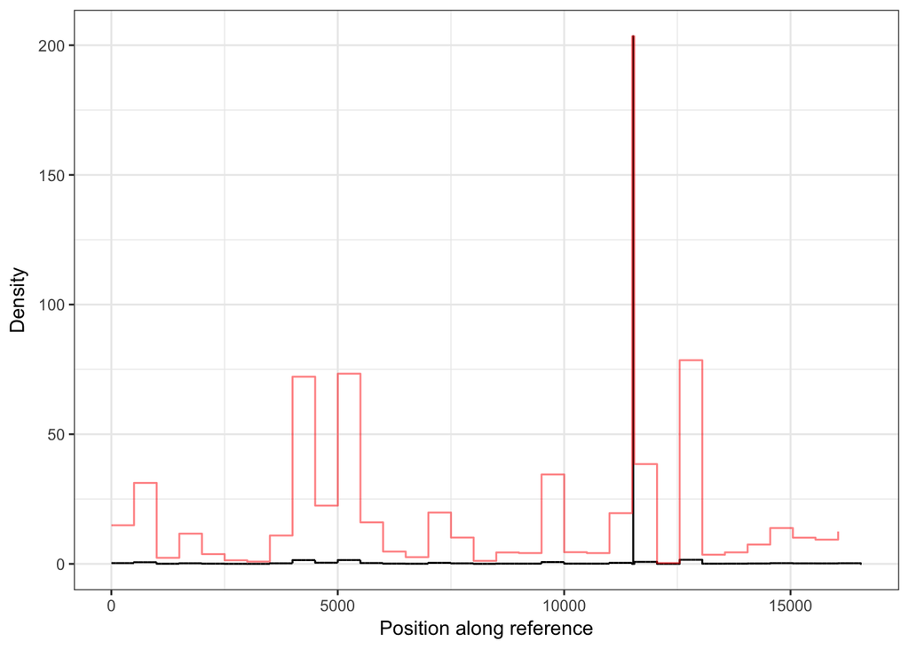

```r
df.site <- cbind.data.frame(
  pos = seq(1, length(dens)),
  dens = dens);
df2 <- cbind.data.frame(
  pos = sapply(features, "[[", 1),
  weight = sapply(features, "[[", 3),
  sapply(features, class)[1, ]);
gg <- ggplot(df.site, aes(x = pos, y = dens));
gg <- gg + geom_line();
gg <- gg + geom_step(data = df2, aes(x = pos, y = weight), colour = "red", alpha = 0.5);
gg <- gg + theme_bw();
gg <- gg + labs(
  x = "Position along reference",
  y = "Density");
gg;
```

We also show the binding site density within a 10kb window around the largest peak on a log10 scale.

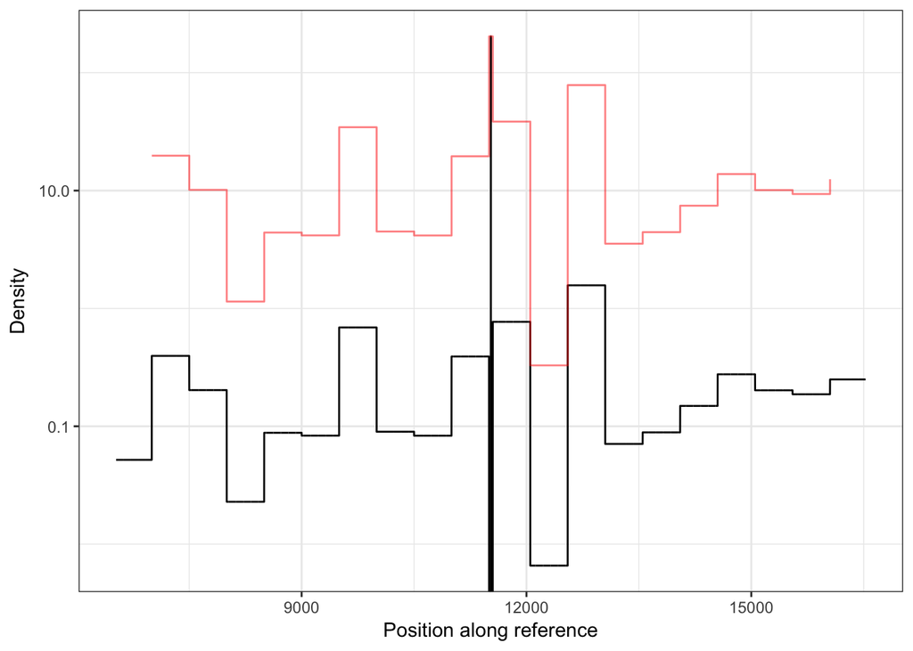

```r
range <- 5000;
xpeak <- which.max(df.site$dens);   # Position of largest peak
gg <- ggplot(df.site[xpeak - seq(-range, range), ]);
gg <- gg + geom_line(aes(x = pos, y = dens));
gg <- gg + geom_step(data = df2[which(abs(df2$pos - xpeak) <= range), ],
                     aes(x = pos, y = weight),
                     colour = "red",
                     alpha = 0.5);
gg <- gg + theme_bw();
gg <- gg + labs(
  x = "Position along reference",
  y = "Density");
gg <- gg + scale_y_log10();
gg;
```

# 6 From DNA fragment to reads

**Comment:** According to the `ChIPsim` vignette, the function `ChIPsim::bindDens2readDens` generates read densities for the forward and reverse strand. I find this description ambiguous; in fact the function simulates *DNA fragment densities* from both strands. *Reads* are simulated in a subsequent step, using the functions `ChIPsim::sampleReads` and `ChIPsim::pos2fastq`. However to maintain consistency with the vignette description, I will continue to refer to “read densities” in the context of `ChIPsim::bindDens2readDens`.

## 6.1 DNA fragment size distribution

We first define a DNA fragment size distribution function. We parametrise the size distribution by a normal distribution, with a minimum, maximum and mean DNA size. We estimate the standard deviation of the normal size distribution from the range
$$\begin{equation}
\text{sd} = \frac{\text{max} - \text{min}}{4}\,.
\end{equation}$$

```r
fragLength <- function(x, minLength, maxLength, meanLength, ...) {
  sd <- (maxLength - minLength)/4;
  prob <- dnorm(minLength:maxLength, mean = meanLength, sd = sd);
  prob <- prob/sum(prob);
  return(prob[x - minLength + 1]);
}
```

## 6.2 Read density distribution

We can now generate read densities (better: DNA fragment densities) for the forward and reverse strand using the binding site densities `dens` and DNA fragment size distribution function `fragLength`.

```r
readDens <- ChIPsim::bindDens2readDens(
  dens,
  fragLength,
  bind = 50,
  minLength = 150,
  maxLength = 250,
  meanLength = 200);
```

Here, we have assumed a DNA fragment size distribution with parameters
$$\begin{align*}
\mu &= 200\text{ bp}\\
\text{min} &= 150\text{ bp}\\
\text{max} &= 250\text{ bp}\,.
\end{align*}$$

**Comment:** Following the example from the vignette, we pass the argument `bind = 50` to `ChIPsim::bindDens2readDens`, even though we don’t use the length of the binding site in the fragment size distribution function. From the vignette, page 13: “Here we do not use the length of the binding site but our function either needs a bind argument or use ‘. . .’ to absorb any additional arguments.” The function `ChIPsim::bindDens2readDens` samples DNA fragment sizes from the range `(minlength:maxLength) - bind`. So we *must* specify the binding site length when calling the function.

We plot binding site and read densities around the largest peak within a 1kb window on a log10 scale.

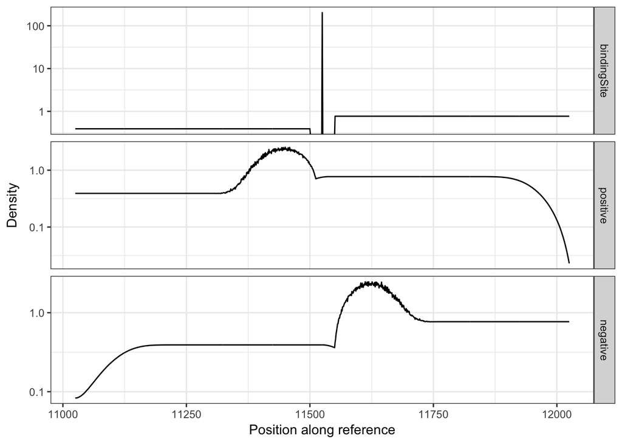

```r
range <- 500;
df.DNA <- cbind.data.frame(
  pos = seq(1, nrow(readDens)),
  readDens);
colnames(df.DNA)[2:3] <- c("positive", "negative");
df.DNA <- melt(df.DNA, id.vars = "pos");
df <- rbind.data.frame(
  cbind.data.frame(pos = df.site$pos,
                   variable = "bindingSite",
                   value = df.site$dens),
  df.DNA);
gg <- ggplot(subset(df, abs(pos - xpeak) <= range));
gg <- gg + geom_line(aes(x = pos, y = value));
gg <- gg + facet_grid(variable ~ ., scales = "free_y");
gg <- gg + theme_bw();
gg <- gg + labs(
  x = "Position along reference",
  y = "Density");
gg <- gg + scale_y_log10();
gg;
```

## 6.3 Sampling reads

We can now sample read positions from the DNA fragment densities.

```r
readLoc <- ChIPsim::sampleReads(readDens, nreads = 1e5);
```

The result is a `list` of two integer vectors containing read start positions from the forward and reverse strand.

We can convert read start positions into read sequence and quality strings using `ChIP::pos2fastq`. To do so, we first define a function to generate uniformly random read qualities using the Phred+33 quality score encoding.

```r
randomQualityPhred33 <- function(read, ...) {
  # Character vector of symbols for the Phred+33 quality encoding scale
  rangePhred33 <- unlist(strsplit(rawToChar(as.raw(33:126)), ""));
  # Uniform-randomly sample qualities
  paste(sample(rangePhred33, length(read), replace = TRUE), collapse = "");
}
```

Based on sampled read positions, we extract reads from the reference sequence and store the output in a FASTQ file.

```r
# Read length
readLength <- 100;

# We need to make sure that readLoc + readLen <= refLength for both strands
readLoc[[1]] <- readLoc[[1]][which(readLoc[[1]] + readLength <= refLength)];
readLoc[[2]] <- readLoc[[1]][which(readLoc[[1]] - readLength > 0)];

# Create names
nreads <- sapply(readLoc, length);
names <- list(fwd = sprintf("read_fwd_%s", seq(nreads[1])),
              rev = sprintf("read_rev_%s", seq(nreads[2])));

# Write to FASTQ
# Uncomment for output
#pos2fastq(readLoc,
#          names = names,
#          sequence = genome[[1]],
#          qualityFun = randomQualityPhred33,
#          errorFun = readError,
#          readLen = readLength,
#          file = "TF_ChIP_MT.fastq");
```

**Comment:** The function `ChIPsim::pos2fastq` does not automatically check if `readLoc + readLen <= refLength`, so we need to do this manually prior to calling `ChIPsim::pos2fastq`; the function generates sequencing errors based on an error model that performs single nucleotide substitutions depending on simulated read qualities. This seems to be the default mode. Lastly, output is written to a FASTQ file using the function `ChIPsim::writeFASTQ`, which unfortunately does not allow for gzip’ed FASTQ output. Best to not use `ChIPsim::pos2fastq`, and instead generate reads and read qualities manually, and write output to a gzipped FASTQ file using the `ShortRead` library.

# 7 Appendix A: `bindDens2readDens`

```r
bindDens2readDens <- function(
  bindDens,
  fragment,
  nfrag = 1e+05,
  bind = 147,
  minLength = 150,
  maxLength = 180, ...) {
  fragSample <- sample(
    (minLength:maxLength) - bind,
    nfrag,
    replace = TRUE,
    prob = fragment(
      (minLength:maxLength),
      minLength = minLength,
      maxLength = maxLength,
      bind = bind,
      ...))
  step <- 1/(maxLength - bind + 1)
  locDist <- bindLocDens(seq(0, 1, by = step))
  readSample <- round(fragSample * sample(
    seq(0, 1, by = step),
    nfrag,
    prob = locDist,
    replace = TRUE))
  readDist <- hist(
    readSample,
    breaks = -1:(maxLength - bind + 1) + 0.5,
    plot = FALSE)$density
  readDist <- readDist/sum(readDist)
  readKernel <- c(rep(0, floor(bind * 0.5)), readDist)
  readKernel <- c(
    readKernel,
    rep(0, nextn(length(readKernel)) - length(readKernel)))
  n <- length(bindDens)
  bindDens <- c(
    bindDens,
    rep(0, nextn(n + length(readKernel) - 1) - (n + length(readKernel) - 1)))
  idx <- list((length(readDist) + floor(bind * 0.5) + 1):(n +
        length(readDist) + floor(bind * 0.5)), 1:n)
  readDens <- cbind(
    convolve(bindDens, readKernel, type = "open")[idx[[1]]],
    convolve(bindDens, rev(readKernel), type = "open")[idx[[2]]])
  readDens <- apply(readDens, 2, function(x) ifelse(x < 0, 0, x))
  readDens
}
```

The function `bindDens2readDens` does the following:

1. In lines 8-17 we draw `nfrag` samples with replacement from the population of DNA fragment sizes minus the binding site length, as defined by the sequence `(minLength:maxLength)-bind`. Samples are drawn with probabilities defined by the fragment size distribution `fragment`. In our case, the distribution of samples is a truncated normal distribution with mean `meanFragmentLength` bounded by `minLength = minFragmentLength` below and `maxLength = maxFragmentLength` above.

```r
fragSample <- sample(
  (150:250) - 50,
  1e5,
  replace = TRUE,
  prob = fragLength(150:250, 150, 250, 200));
```

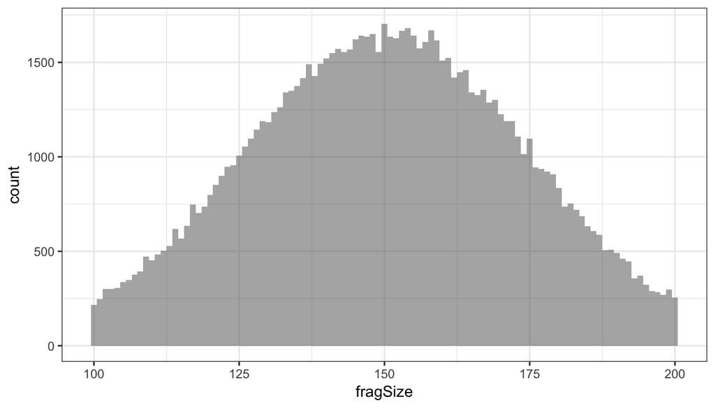

2. In lines 18, 19 `locDist` are the values of the pdf of distribution $\text{Beta}(\alpha = 2, \beta = 2)$ (as defined in `bindLocDens`), evaluated between 0 and 1 with step size `step`.

```r
step <- 1/(250 - 50 + 1);
locDist <- bindLocDens(seq(0, 1, by = step));
```

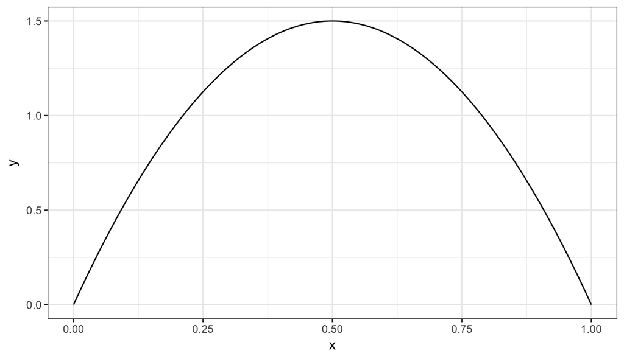

3. In lines 20-29 we generate `nfrag` read samples and extract the underlying pdf.

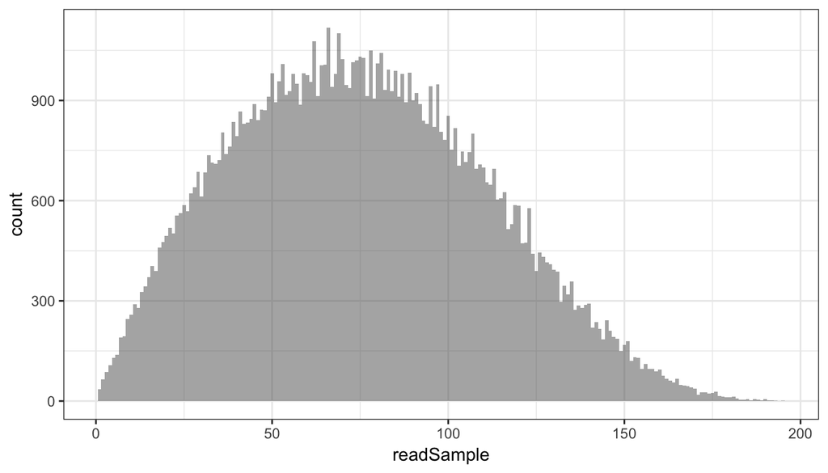

```r
readSample <- round(fragSample * sample(
  seq(0, 1, by = step),
  1e5,
  replace = TRUE,
  prob = locDist));
readDist <- hist(
  readSample,
  breaks = -1:(250 - 50 + 1) + 0.5,
  plot = FALSE)$density
readDist <- readDist/sum(readDist)
```

4. In lines 30-33 we construct the kernel distribution from the read sample pdf `readSample` by shifting the distribution by `bind/2 = bindingLength/2 = 25` and padding with zeros.

```r
readKernel <- c(rep(0, floor(50 * 0.5)), readDist)
readKernel <- c(
  readKernel,
  rep(0, nextn(length(readKernel)) - length(readKernel)))
```

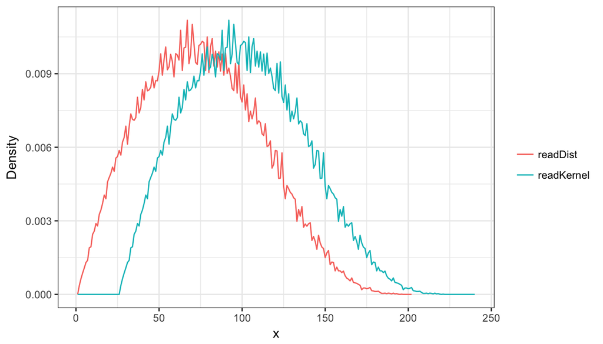

4. Final density distribution is the convolution of the binding density and read density distributions
   $$\begin{equation}
   f_\rho(z) = \sum_{x=0}^z f_w(x) f_r(z-x)
   \end{equation}$$